# Multiple Hypothesis Testing

Chris

11/22/2019

## Multiple Hypothesis Testing

Lets load that giant data set from HW9

```r
data.file.name <- "HW9_EXPRESSION_DATA.tsv.gz"
data.file.object <- gzfile(data.file.name)
expression.data <- read.delim(data.file.object)

meta.data.file.name <- "HW9_SAMPLE_DATA.tsv"
meta.data <- read.delim(meta.data.file.name)
```

## Let’s do differential gene expression between YPDXX and RAPAXX biological samples

I’m going to break this into two data sets for convenience

```r
# Filter out anything that's all 0s

expression.data <- expression.data[rowSums(expression.data) > 0,]

ypd.expression <- as.data.frame(t(expression.data[, 1:70]))
rapa.expression <- as.data.frame(t(expression.data[, 71:140]))
```

Now I’m going to t-test every single gene. All of them.

```r
# Step 1: pick one gene to test

test.gene <- "YKR039W"

sample_1_gene <- ypd.expression[, test.gene]
sample_2_gene <- rapa.expression[, test.gene]
tt <- t.test(sample_1_gene, sample_2_gene)

print(c(tt$statistic, tt$p.value, mean(sample_1_gene), mean(sample_2_gene)))
```

```
##             t
## -1.588817e+01  9.464548e-25  1.642857e+00  5.299714e+02
```

```r
# Step 2: make that thing I just wrote into a function
gene.diff.test <- function(test.gene, sample_1, sample_2) {
  sample_1_gene <- sample_1[, test.gene]
  sample_2_gene <- sample_2[, test.gene]
  tt <- t.test(sample_1_gene, sample_2_gene)
  return(c(tt$statistic, tt$p.value, mean(sample_1_gene), mean(sample_2_gene)))
}
```

```r
# Step 3: Does my function work?
print(gene.diff.test("YKR039W", ypd.expression, rapa.expression))
```

```
##             t
## -1.588817e+01  9.464548e-25  1.642857e+00  5.299714e+02
```

```r
# Step 4: Run the code that I KNOW WORKS in an iterative loop

test.values <- mapply(gene.diff.test, test.gene=colnames(ypd.expression), MoreArgs = list(sample_1=ypd.expression, sample_2=rapa.expression))

test.values <- as.data.frame(t(test.values))
colnames(test.values) <- c("t", "pval", "YPD.mean", "RAPA.mean")

# And make sure it matches what I got before:
print(test.values["YKR039W",])
```

```
##                 t         pval YPD.mean RAPA.mean
## YKR039W -15.88817 9.464548e-25 1.642857  529.9714
```

How many genes have p-values less than 0.05?

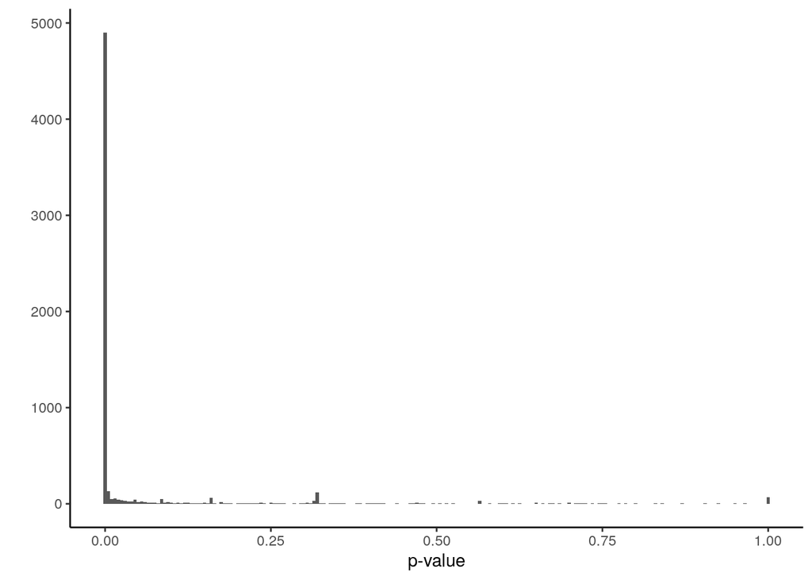

```r
qplot(test.values$pval, geom="histogram", binwidth=0.005) + labs(x="p-value")
```

```r
sig.genes <- sum(test.values$pval < 0.05)
print(paste("Significant genes (p < 0.05) :", sig.genes))
```

```
## [1] "Significant genes (p < 0.05) : 5345"
```

How many genes do we expect are Type I errors (false positives)?

```r
print(paste("Type I errors (p < 0.05) :", ncol(ypd.expression) * 0.05))
```

```
## [1] "Type I errors (p < 0.05) : 320.65"
```

What is the expected FALSE DISCOVERY RATE?

```r
print(paste("Expected FALSE DISCOVERY RATE :", ncol(ypd.expression) * 0.05 / sig.genes))
```

```
## [1] "Expected FALSE DISCOVERY RATE : 0.0599906454630496"
```

Well that’s not… terrible I guess. I’d like to control my false discovery rate to 0.01 though. What p-value threshold gives me a false discovery rate of 0.01?

```r
for (i in 1:10) {
  pv <- 0.05 / i
  print(paste("Expected FALSE DISCOVERY RATE (p <",
              round(pv, digits=3), "):",
              round(ncol(ypd.expression) * pv /sum(test.values$pval < pv), digits = 4)))
}
```

```
## [1] "Expected FALSE DISCOVERY RATE (p < 0.05 ): 0.06"
## [1] "Expected FALSE DISCOVERY RATE (p < 0.025 ): 0.0308"
## [1] "Expected FALSE DISCOVERY RATE (p < 0.017 ): 0.0208"
## [1] "Expected FALSE DISCOVERY RATE (p < 0.012 ): 0.0158"
## [1] "Expected FALSE DISCOVERY RATE (p < 0.01 ): 0.0127"
## [1] "Expected FALSE DISCOVERY RATE (p < 0.008 ): 0.0106"
## [1] "Expected FALSE DISCOVERY RATE (p < 0.007 ): 0.0091"
## [1] "Expected FALSE DISCOVERY RATE (p < 0.006 ): 0.008"
## [1] "Expected FALSE DISCOVERY RATE (p < 0.006 ): 0.0071"
## [1] "Expected FALSE DISCOVERY RATE (p < 0.005 ): 0.0064"
```

As the p-value goes down, so does the false discovery rate - it looks like p < 0.008 is a good cutoff for significance to control my false discovery rate to 0.01.

```r
sig.genes <- sum(test.values$pval < 0.008)
print(paste("Significant genes (p < 0.008) :", sig.genes))
```

```
## [1] "Significant genes (p < 0.008) : 5037"
```

```r
print(paste("Type I errors (p < 0.008) :", ncol(ypd.expression) * 0.008))
```

```
## [1] "Type I errors (p < 0.008) : 51.304"
```

```r
print(paste("Expected FALSE DISCOVERY RATE :", ncol(ypd.expression) * 0.008 / sig.genes))
```

```
## [1] "Expected FALSE DISCOVERY RATE : 0.0101854278340282"
```

That’s still a lot of differences. Is there a function that does this for us though?

Of course there is. This is R.

```r
test.values$p.adj <- p.adjust(test.values$pval, method = "fdr")
sig.genes <- sum(test.values$p.adj < 0.01)
print(paste("Significant genes (q < 0.01) :", sig.genes))
```

```
## [1] "Significant genes (q < 0.01) : 5036"
```

## I am interested in the differential expression between rapamycin-treated samples. Specifically I am interested in comparing the wild-type (`TF == "WT"`) biological samples to the other biological samples

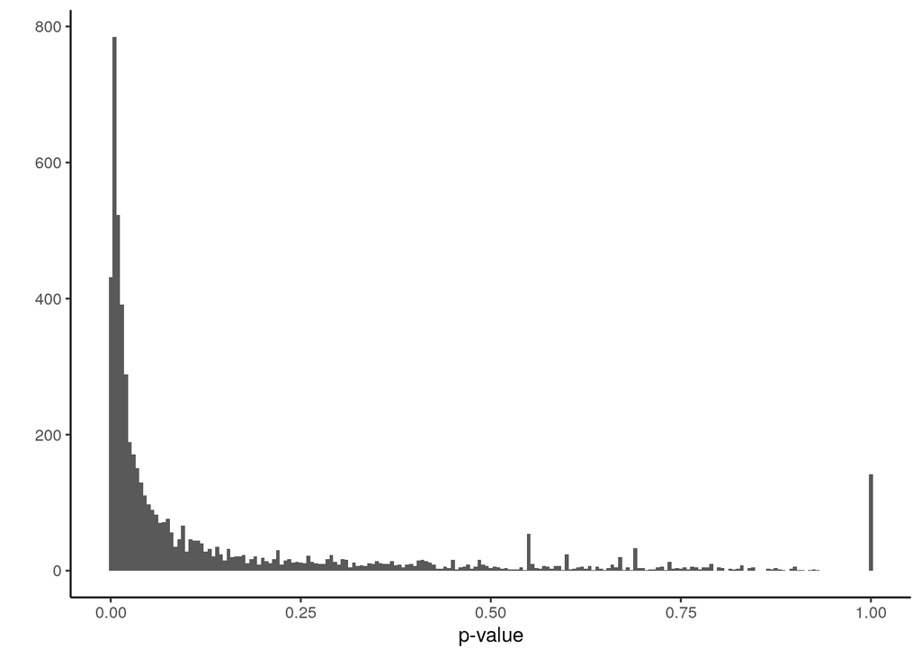

```r
# I'm going to select the data that I want
wt.rapa <- meta.data$Experiment == "RAPA" & meta.data$TF == "WT"
wt.rapa.data <- as.data.frame(t(expression.data[, wt.rapa]))

gcn4.rapa <- meta.data$Experiment == "RAPA" & meta.data$TF == "gcn4"
gcn4.rapa.data <- as.data.frame(t(expression.data[, gcn4.rapa]))

# Run my test function again with mapply
gcn4.test.values <- mapply(gene.diff.test, test.gene=colnames(wt.rapa.data), MoreArgs = list(sample_1=wt.rapa.data, sample_2=gcn4.rapa.data))

gcn4.test.values <- as.data.frame(t(gcn4.test.values))
colnames(gcn4.test.values) <- c("t", "pval", "WT.mean", "GCN4.mean")

# And I'm going to get rid of all the columns where WT.mean and GCN4.mean are both 0
gcn4.test.values <- gcn4.test.values[gcn4.test.values$WT.mean != 0 & gcn4.test.values$GCN4.mean != 0,]

# Now I'll add a column for the fdr-corrected p.adj values
gcn4.test.values$p.adj <- p.adjust(gcn4.test.values$pval, method = "fdr")

qplot(gcn4.test.values$pval, geom="histogram", binwidth=0.005) + labs(x="p-value")
```

```r
print(paste("Significant genes (p < 0.05) :", sum(gcn4.test.values$pval < 0.05)))
```

```
## [1] "Significant genes (p < 0.05) : 3215"
```

```r
print(paste("Significant genes (q < 0.01) :", sum(gcn4.test.values$p.adj < 0.01)))
```

```
## [1] "Significant genes (q < 0.01) : 0"
```